# Epic Cosmos vector-borne diseases

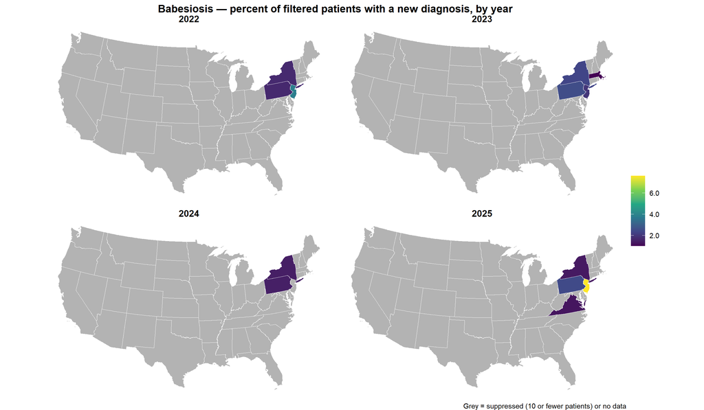

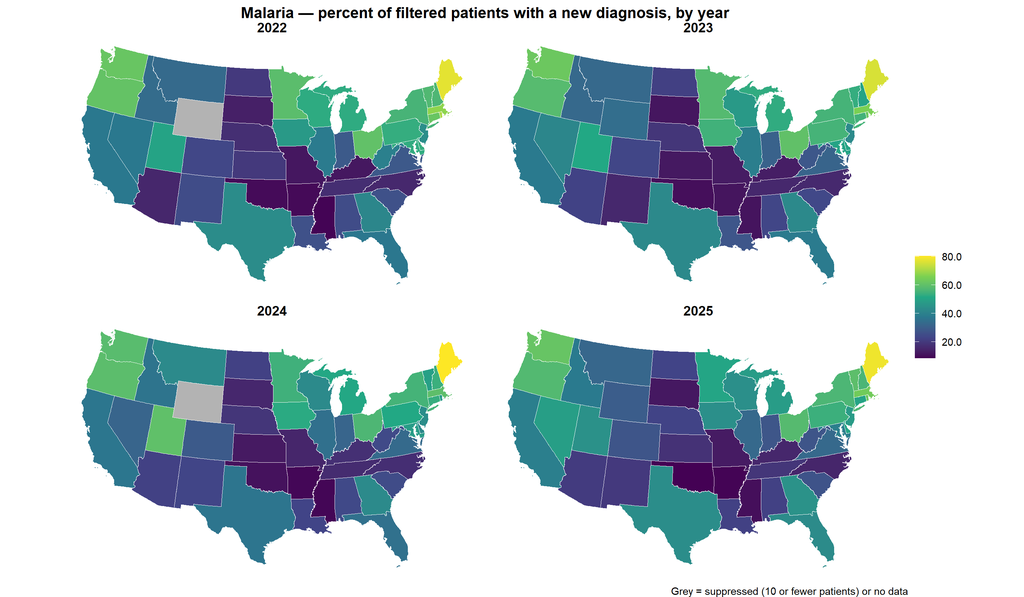

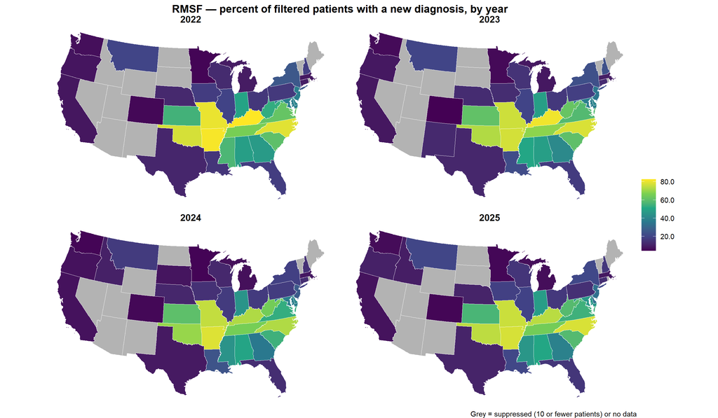

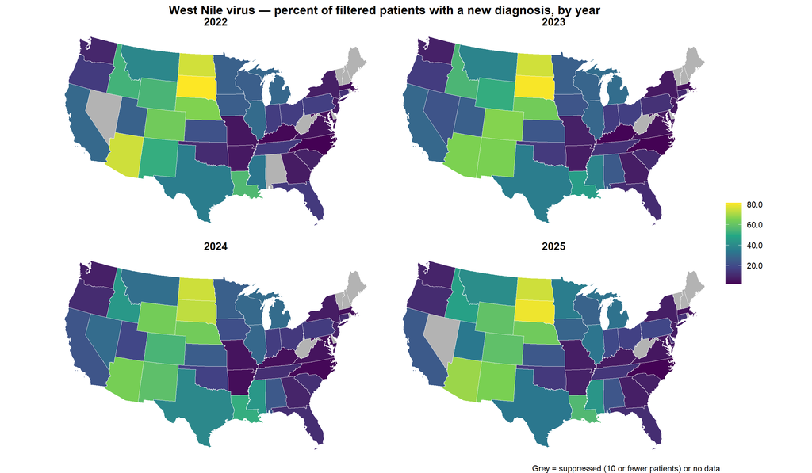

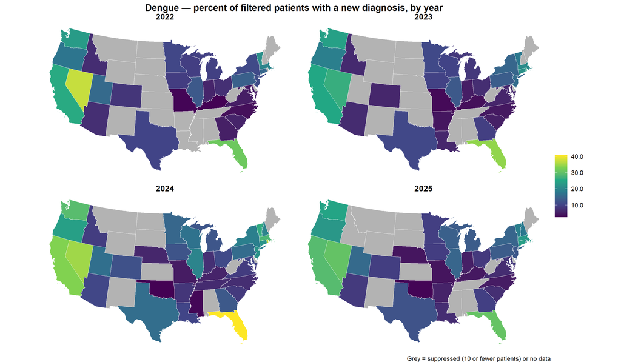

### Comparison: problem list vs. pop filter

Both definitions count patients with a new diagnosis, but the problem-list measure (`data_new_cases.csv.gz`, monthly, all patients) and the pop-filter measure (`data_new_cases_pop_filter.csv.gz`, annual) come from different Cosmos sessions with different definitions of “new”. The problem-list monthly counts are summed to calendar years (complete years 2022-2025); a patient newly diagnosed in two different months is counted twice in that sum.

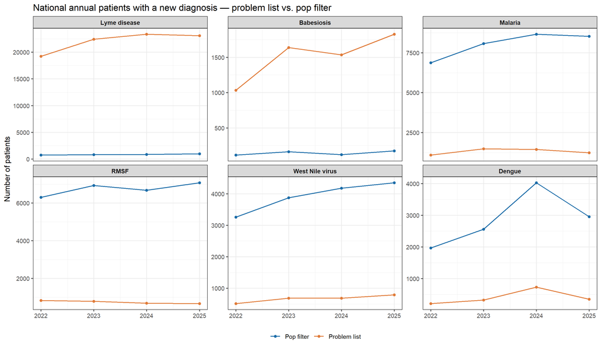

National annual counts, by disease and year

| year | disease | Problem list | Pop filter | Pop filter / problem list |
| --- | --- | --- | --- | --- |
| 2022 | Lyme disease | 19212 | 746 | 0.04 |
| 2023 | Lyme disease | 22413 | 837 | 0.04 |
| 2024 | Lyme disease | 23354 | 877 | 0.04 |
| 2025 | Lyme disease | 23095 | 968 | 0.04 |
| 2022 | Babesiosis | 1034 | 115 | 0.11 |
| 2023 | Babesiosis | 1638 | 163 | 0.10 |
| 2024 | Babesiosis | 1534 | 121 | 0.08 |
| 2025 | Babesiosis | 1826 | 175 | 0.10 |
| 2022 | Malaria | 1097 | 6868 | 6.26 |
| 2023 | Malaria | 1481 | 8070 | 5.45 |
| 2024 | Malaria | 1450 | 8652 | 5.97 |
| 2025 | Malaria | 1240 | 8531 | 6.88 |
| 2022 | RMSF | 829 | 6307 | 7.61 |
| 2023 | RMSF | 783 | 6932 | 8.85 |
| 2024 | RMSF | 687 | 6682 | 9.73 |
| 2025 | RMSF | 665 | 7071 | 10.63 |
| 2022 | West Nile virus | 510 | 3260 | 6.39 |
| 2023 | West Nile virus | 685 | 3876 | 5.66 |
| 2024 | West Nile virus | 681 | 4179 | 6.14 |
| 2025 | West Nile virus | 790 | 4347 | 5.50 |
| 2022 | Dengue | 208 | 1965 | 9.45 |
| 2023 | Dengue | 324 | 2561 | 7.90 |
| 2024 | Dengue | 729 | 4025 | 5.52 |
| 2025 | Dengue | 346 | 2954 | 8.54 |

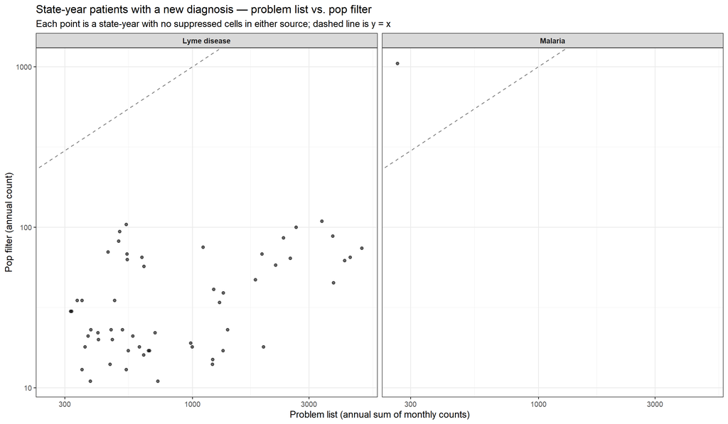

## Testing

Lab component results from Epic Cosmos (`standard/data_lab_tests.csv.gz`, annual, 2022-2025). **Testing volume** is the number of disease-specific test results per 100,000 lab component results of any kind (the denominator is results, not patients). **Test positivity** is approximated as new diagnoses (patients, `data_new_cases.csv.gz`) divided by test results (`n new cases / n tests`); the two come from different Cosmos sessions and count different units, so it is a proxy and can exceed what a true per-test positivity would be. There is no Lyme disease test measure. State-years where the test count, or every month of the new-case count, was suppressed are left blank (maps) or dropped (correlations).

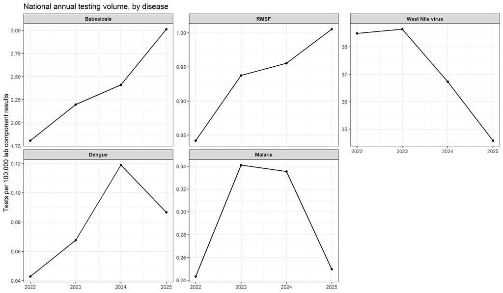

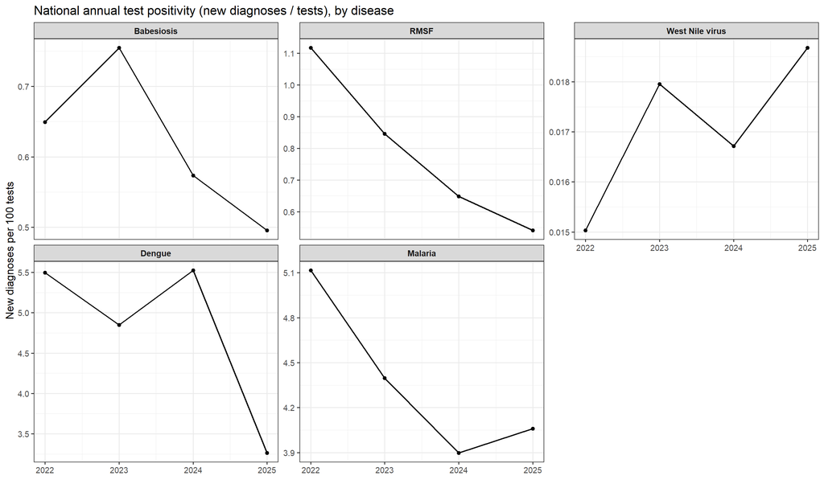

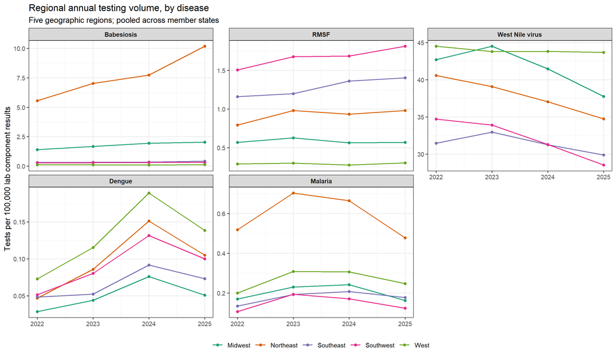

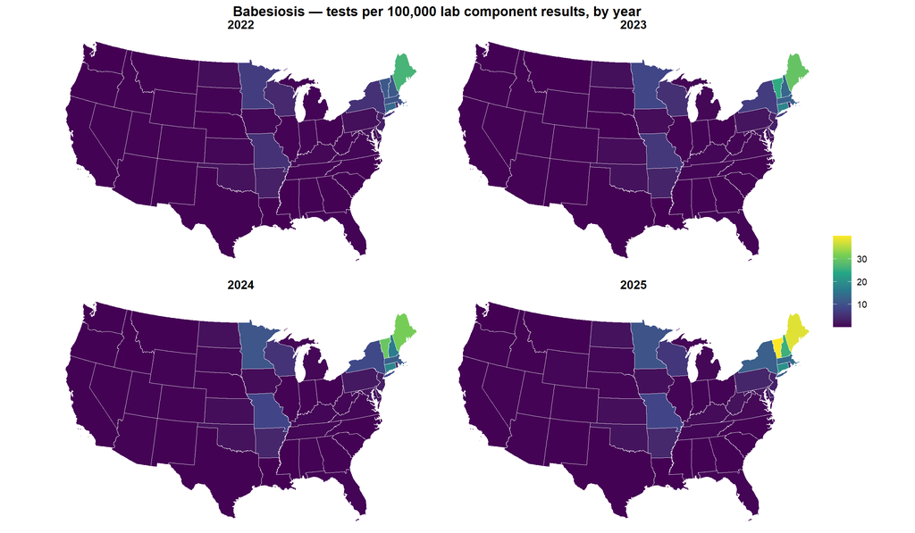

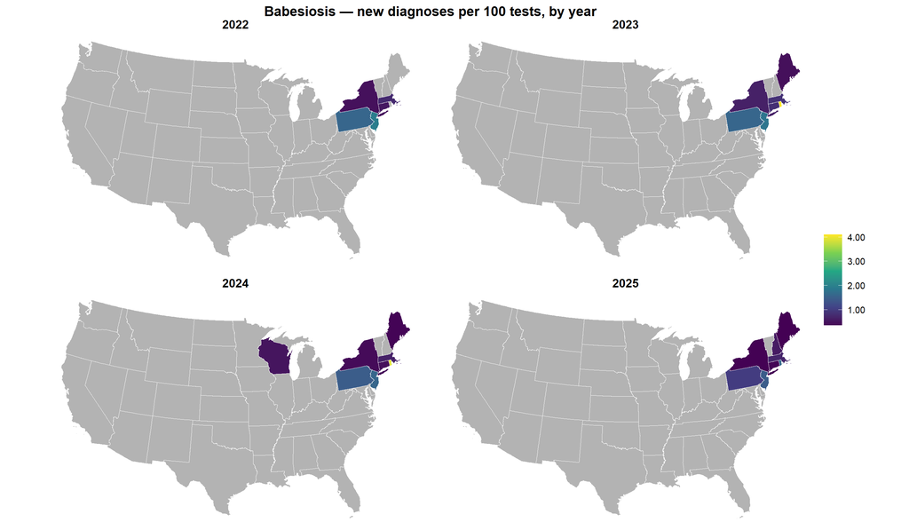

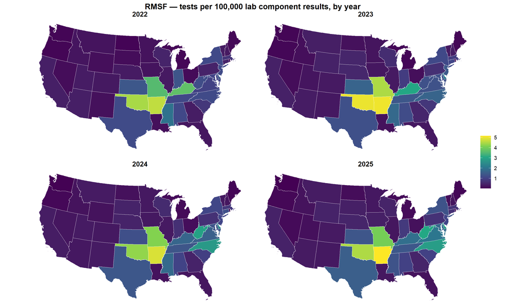

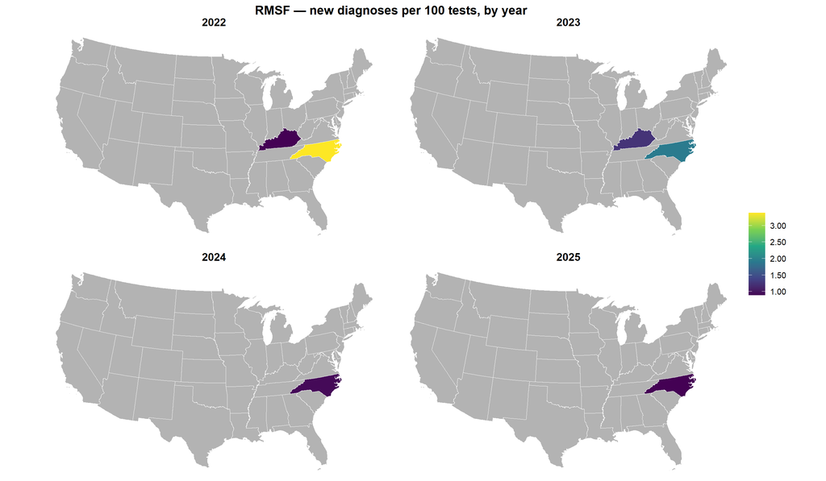

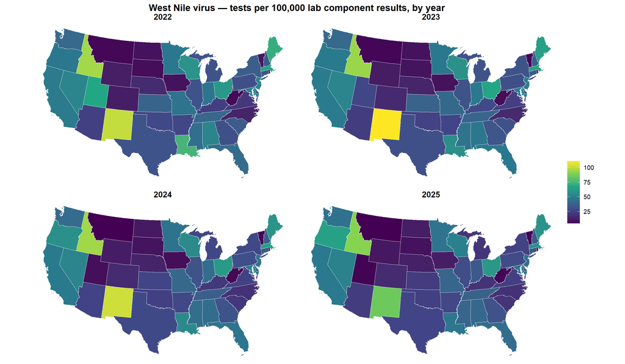

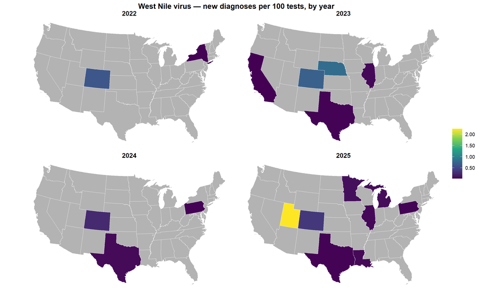

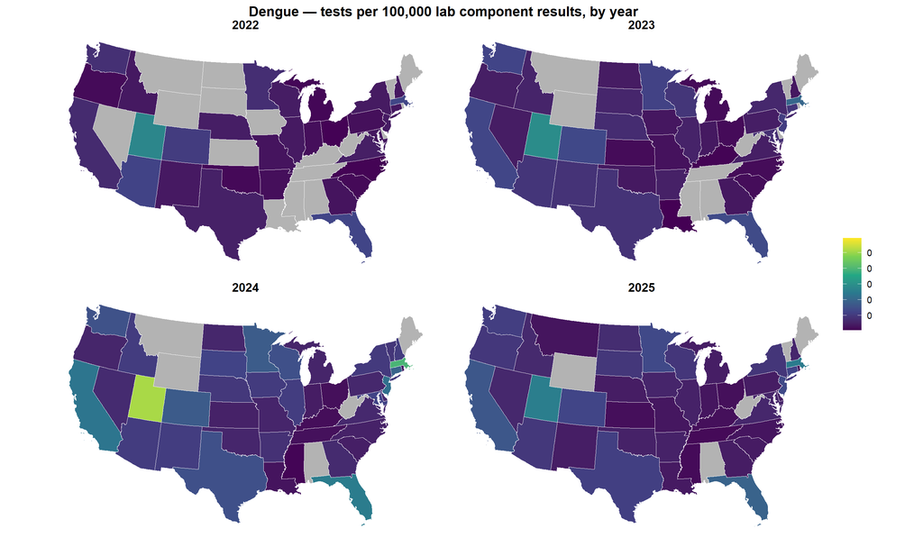

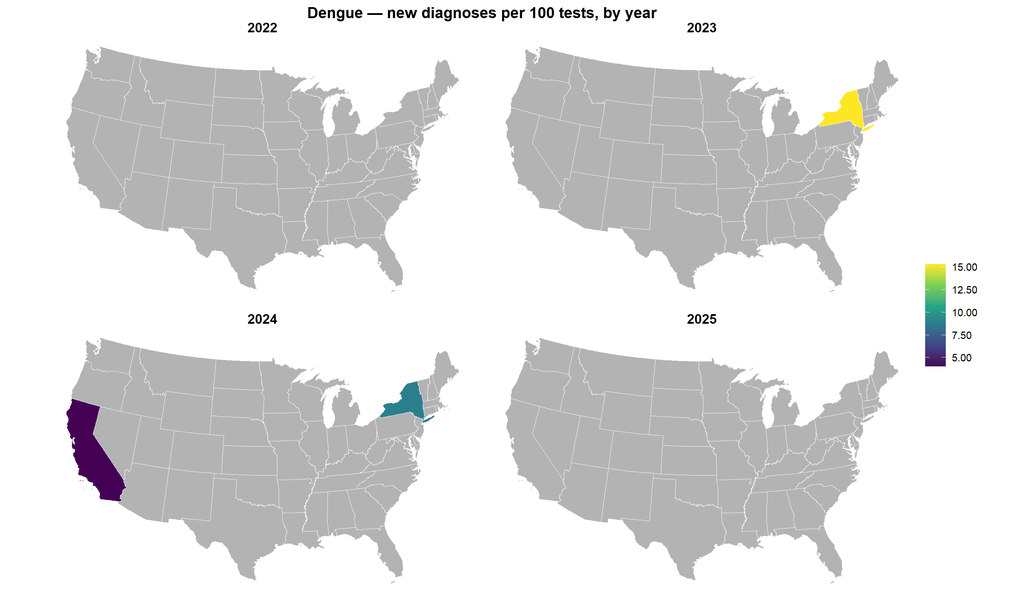

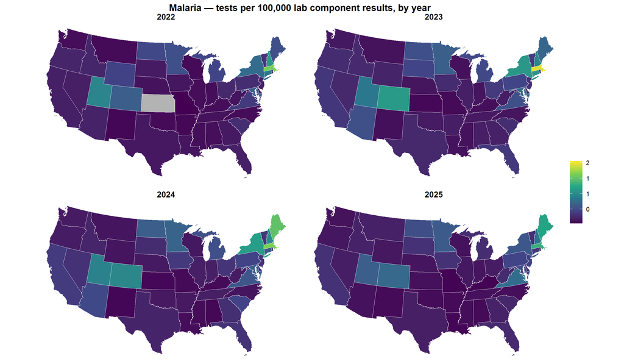

[3 more figures not shown]

Note that the positivity panel shares its numerator (new diagnoses) with the y-axis, so some positive association is expected by construction.

## Comparison with NNDSS and ArboNET

Epic Cosmos counts are compared with the NNDSS and `arbonet`. NNDSS has babesiosis, malaria, West Nile virus and dengue. ArboNET has West Nile virus only.

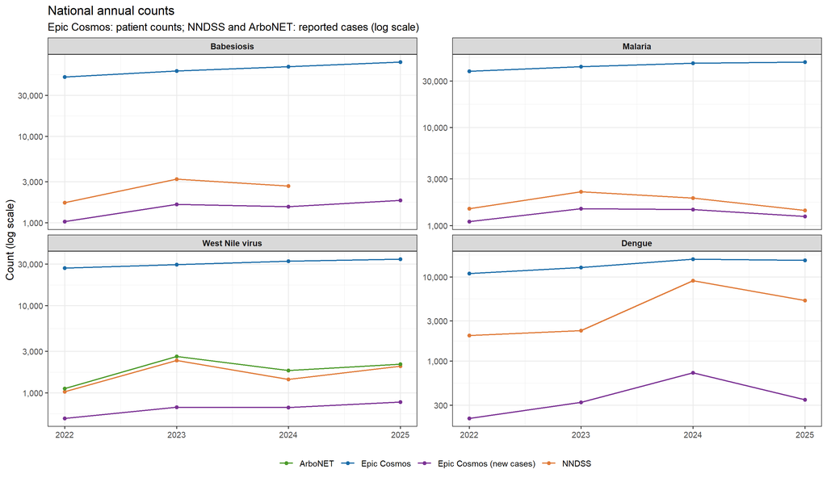

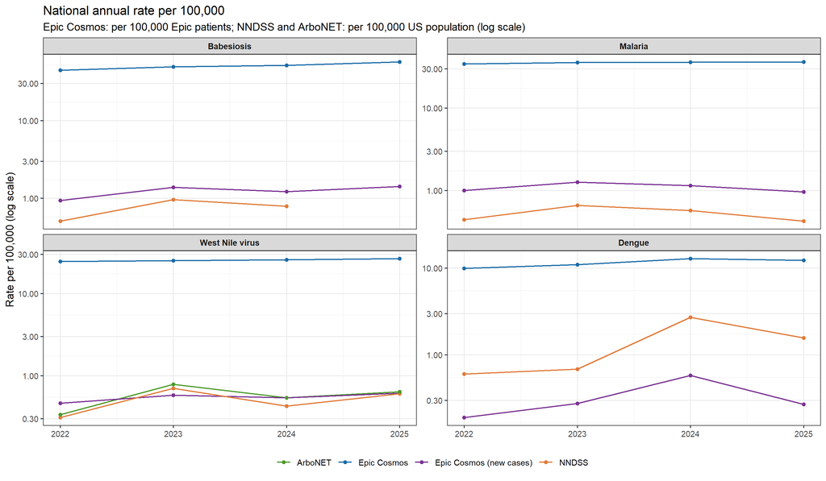

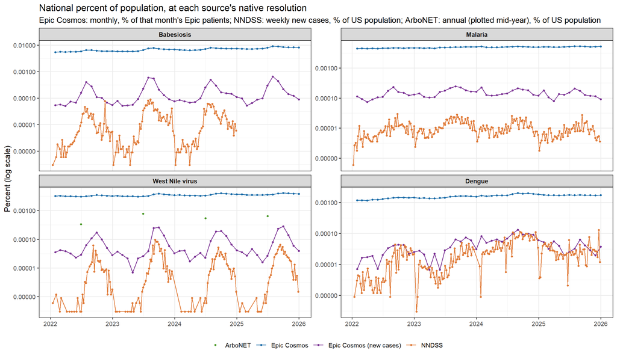

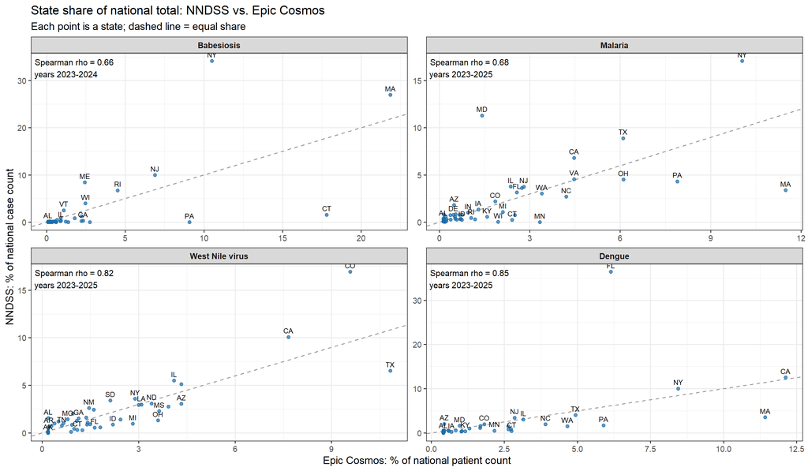

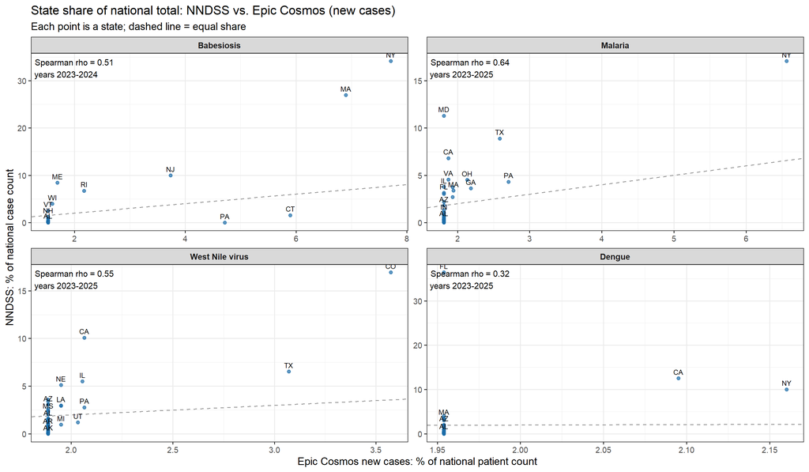

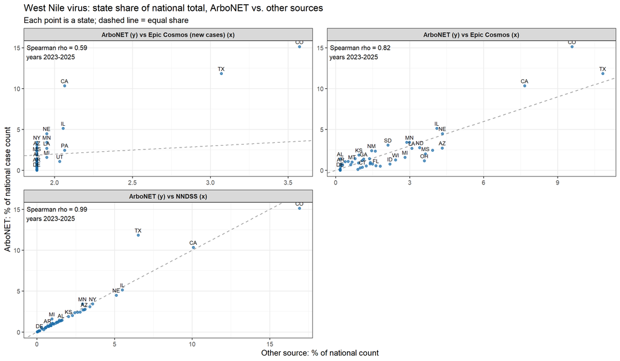

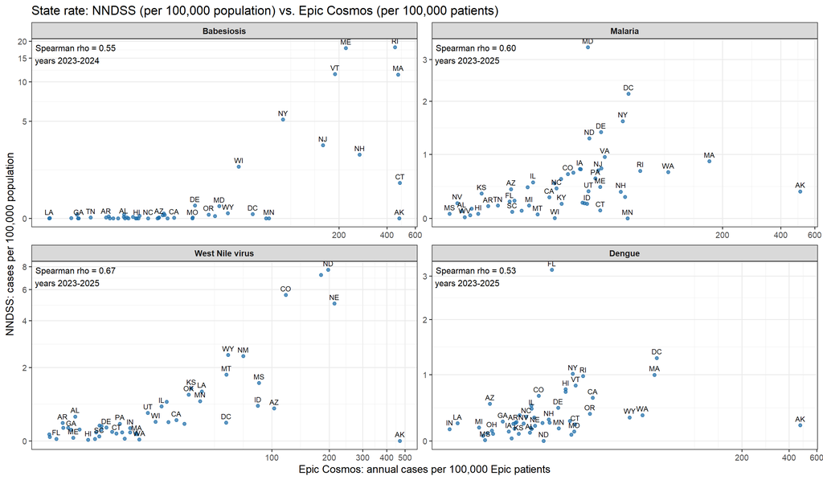

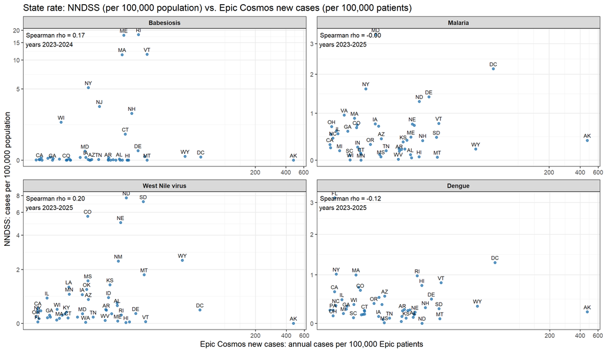

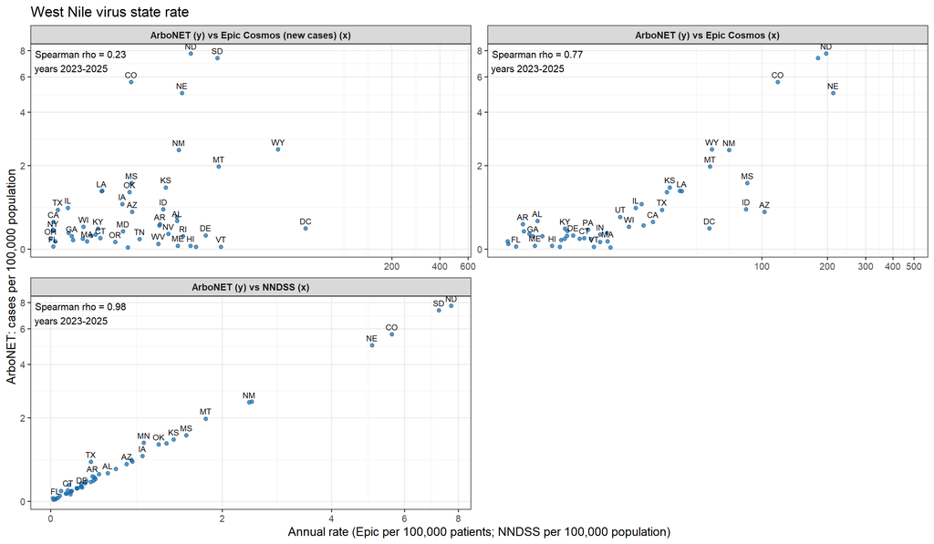